## Alcune ulteriori analisi, con R

Di seguito riportiamo alcune ulteriori analisi, basate su alcuni concetti del corso di *Analisi dei Dati Multidimensionali*, con uno sguardo più approfondito a livello statistico e meno adatto ad un pubblico generalista. Per uniformità, consideriamo solo i partiti che hanno superato il 3% dei consensi nazionali e che erano candidati in tutte le circoscrizioni.

### Analisi delle correlazioni

Per prima cosa, vediamo quanto può dirci l’andamento di un partito sui risultati degli altri

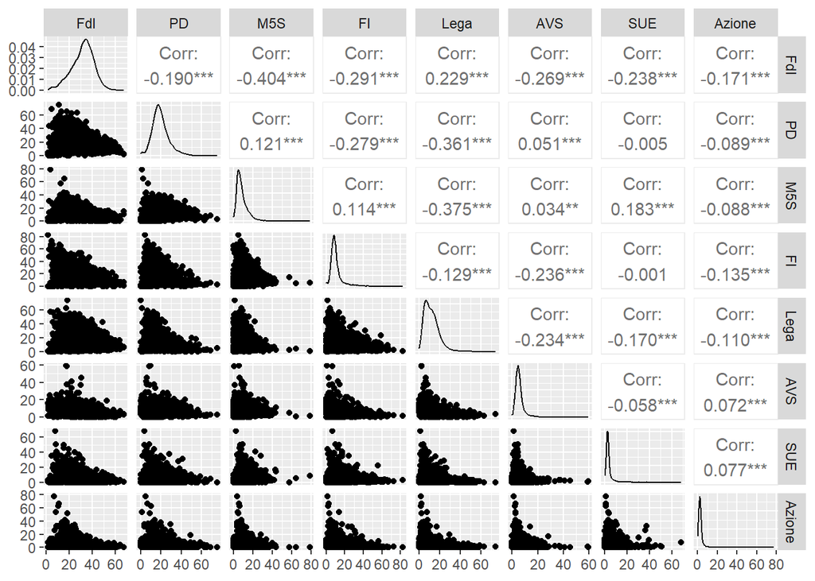

Vediamo come quasi tutte le correlazioni siano significative. Vista la grande dimensione e l’eterogeneità delle unità statistiche, anche correlazioni intorno allo 0.2 risultano interessanti. Notiamo, ad esempio, che un risultato migliore per Fratelli d’Italia porta a percentuali minori per tutti gli altri partiti tranne la Lega. A questo proposito, si può osservare che, mentre Fratelli d’Italia e Lega sono positivamente correlati, la correlazione Forza Italia gli altri due partiti di centrodestra è negativa. Il diverso trend di Forza Italia è consistente con quanto visto in precedenza. Inolte, il Partito Democratico risulta positivamente correlato con il Movimento 5 Stelle e debolmente anche con Alleanza Verdi e Sinistra. Potrebbe risultare sorprendente, infine, la correlazione positiva tra Movimento 5 Stelle e Forza Italia.

### Analisi delle componenti principali

La [*Principal Component Analysis*](https://en.wikipedia.org/wiki/Principal_component_analysis) (PCA) è un metodo di riduzione della dimensionalità con cui cerchiamo di spiegare la variabilità dei dati tramite un minor numero di variabili dette, appunto, componenti principali.

Utilizziamo i dati standardizzati per far emergere la relazione tra i partiti al netto delle loro percentuali medie.

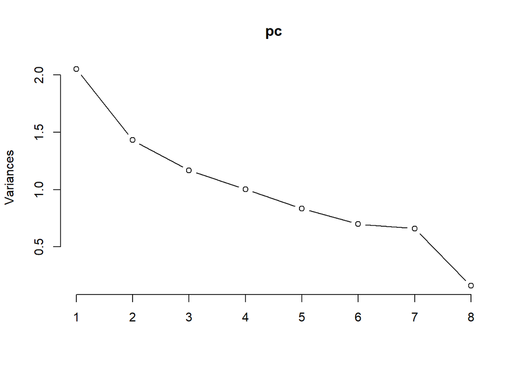

```
## Importance of components:
##                           PC1    PC2    PC3    PC4    PC5     PC6     PC7
## Standard deviation     1.4314 1.1959 1.0798 1.0005 0.9130 0.83614 0.81269
## Proportion of Variance 0.2561 0.1788 0.1457 0.1251 0.1042 0.08739 0.08256
## Cumulative Proportion  0.2561 0.4349 0.5806 0.7058 0.8099 0.89733 0.97989
##                            PC8
## Standard deviation     0.40108
## Proportion of Variance 0.02011
## Cumulative Proportion  1.00000
```

In queste condizioni, vediamo che tre componenti principali da sole spiegano circa il 58% della varianza totale. Per i dati grezzi, invece, due componenti spiegano già il 91%. Ciò è dovuto al fatto che i partiti più piccoli hanno molta meno varianza nei risultati, in termini assoluti, rispetto ai partiti maggiori.

#### Biplot

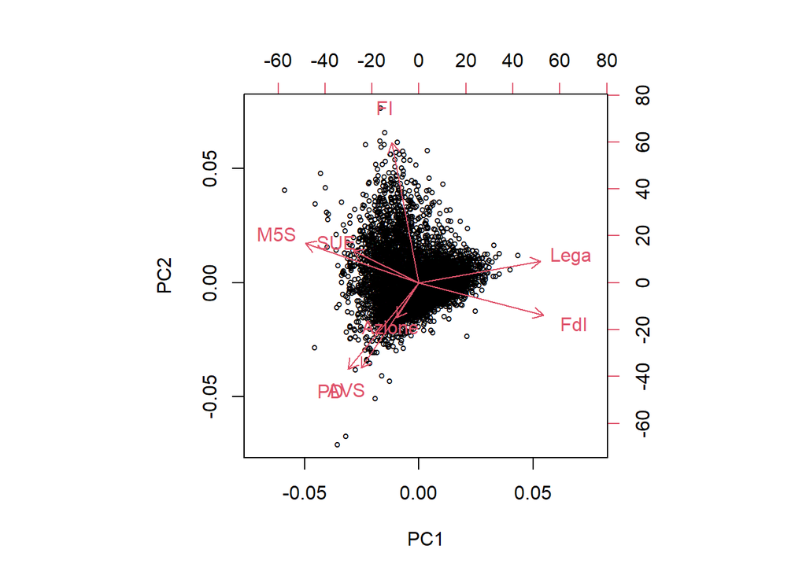

I partiti le cui freccie indicano direzioni simili sono positivamente correlati, quelli a 90° sono incorrelati, mentre quelli che indicano direzioni opposte sono correlati negativamente. Il risultato è tuttavia un’approssimazione basata sulle prime due componenti principali, ovvero spiega solo il 43.5% della varianza totale.

### Analisi fattoriali

La [*Factor Analysis*](https://en.wikipedia.org/wiki/Factor_analysis) (FA) è una tecnica di riduzione della dimensionalità simile alla PCA. Tuttavia, si differenza nel fatto che interpreta le p (nel nostro caso 8) variabili osservate come risultato della realizzazione di m<<p varaibili non osservabili (dette, appunto, fattori).

```r
factanal(X, 4)
```

```
##
## Call:
## factanal(x = X, factors = 4)
##
## Uniquenesses:
##    FdI     PD    M5S     FI   Lega    AVS    SUE Azione
##  0.419  0.005  0.688  0.005  0.678  0.005  0.788  0.898
##
## Loadings:
##        Factor1 Factor2 Factor3 Factor4
## FdI    -0.285  -0.345  -0.298  -0.540
## PD      0.979  -0.186
## M5S     0.165   0.127           0.517
## FI              0.986  -0.110
## Lega   -0.419  -0.194  -0.237  -0.229
## AVS            -0.124   0.988
## SUE                             0.456
## Azione -0.109  -0.147           0.256
##
##                Factor1 Factor2 Factor3 Factor4
## SS loadings      1.268   1.217   1.143   0.885
## Proportion Var   0.158   0.152   0.143   0.111
## Cumulative Var   0.158   0.311   0.454   0.564
##
## Test of the hypothesis that 4 factors are sufficient.
## The chi square statistic is 2822.55 on 2 degrees of freedom.
## The p-value is 0
```

Ci si potrebbe perdere nell’interpretazione dei fattori, ma il test sulla bontà di questa riduzione di dimensionalità ha p-value indistinguibile da 0. Pertanto, l’analisi dei fattori non si presta bene a questo dataset.